# BigWig tools

Carmen Navarro

2020-05-27

```r
library(elsasserlib)
library(ggplot2)
library(rtracklayer)
```

## Summary

This module contains functions to handle BigWig files to perform analyses we usually do, like summarizing the information across *loci* in a `BED` file or making a binned analysis of a set of `BigWig` files.

## Binned analysis

This includes functionality to make bins as `GRanges` objects and intersect `BigWig` files with those.

### Making a GRanges object as a binned genome

To do this, you only need to call the function `build_bins`:

```r
mm9.genome.bins.10000 <- build_bins(bsize=10000, genome="mm9")

head(mm9.genome.bins.10000)
```

```
#> GRanges object with 6 ranges and 0 metadata columns:
#>       seqnames      ranges strand
#>          <Rle>   <IRanges>  <Rle>
#>   [1]     chr1     1-10000      *
#>   [2]     chr1 10001-20000      *
#>   [3]     chr1 20001-30000      *
#>   [4]     chr1 30001-40000      *
#>   [5]     chr1 40001-50000      *
#>   [6]     chr1 50001-60000      *
#>   -------
#>   seqinfo: 35 sequences (1 circular) from mm9 genome
```

`build_bins` relies on `GenomeInfoDb` package and additional data contained in `BSgenome.Mmusculus.UCSC.mm9` and `BSgenome.Hsapiens.UCSC.hg38`, from which it takes sequence info necessary to build the bins. I included these because in the lab we mostly use these two references. If you want to use another genome, you will have to make the tiling yourself. This is pretty easy, really (see documentation on `tileGenome` to do this).

### Making a binned summary of a BigWig file

You can use the function `bw_bins` for this.

```r
# Example bw file included in the package.
# Note: this should be a path for an actual file.
bw.file <- system.file("extdata", "example.1000bs.bw", package = "elsasserlib")

# Now we bin it
binned.score <- bw_bins(bw.file, bsize=10000)

head(binned.score)
```

```
#> GRanges object with 6 ranges and 1 metadata column:
#>       seqnames      ranges strand |     score
#>          <Rle>   <IRanges>  <Rle> | <numeric>
#>   [1]     chr1     1-10000      * |         0
#>   [2]     chr1 10001-20000      * |         0
#>   [3]     chr1 20001-30000      * |         0
#>   [4]     chr1 30001-40000      * |         0
#>   [5]     chr1 40001-50000      * |         0
#>   [6]     chr1 50001-60000      * |         0
#>   -------
#>   seqinfo: 35 sequences from an unspecified genome; no seqlengths
```

Yes, not very informative, since signal at the first bins is zero. To test that this actually worked, we can plot the scores.

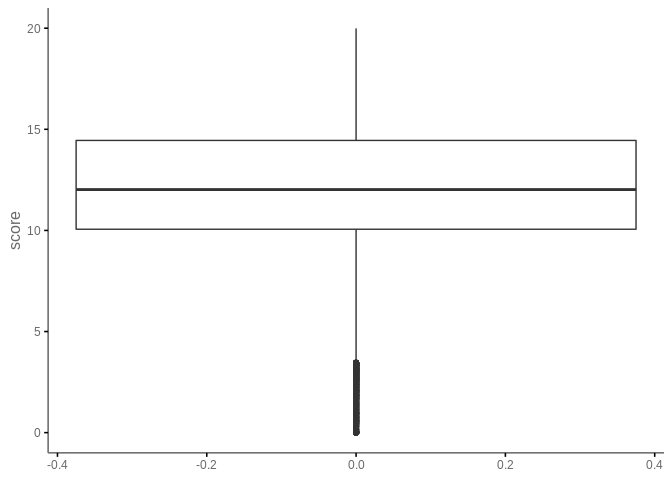

```r
# Convert to dataframe
df <- as.data.frame(binned.score)

ggplot(df, aes(y=score)) +
  geom_boxplot() +
  ylim(0,20) +
  theme_elsasserlab_screen()
```

Note that the `bw_bins` operation is **not immediate**. It will take some seconds to execute in a regular laptop. In my experience, it goes between 30-40 seconds depending on the size of the `bigWig` file for bin sizes of `5000`-`10000`. If you want higher resolutions, consider precomputing these values beforehand.

## Locus-based analysis

You can also intersect a `bigWig` file with a set of loci specified in a `BED` file using `bw_bed`:

```r
# Example bw file included in the package.
# Note: this should be a path for an actual file.
bw.file <- system.file("extdata", "example.1000bs.bw", package = "elsasserlib")
bed.file <- system.file("extdata", "ChromHMM7_subsample.bed", package = "elsasserlib")

# We intersect these two files
summary.score <- bw_bed(bw.file, bed.file, per.locus.stat = "mean")

# We get a GRanges object which one score per locus
head(summary.score)
```

```
#> GRanges object with 6 ranges and 1 metadata column:
#>       seqnames            ranges strand |            score
#>          <Rle>         <IRanges>  <Rle> |        <numeric>
#>   [1]    chr15 77144201-77144800      * | 126.165000915527
#>   [2]    chr13 81778401-81781000      * | 36.4592461952796
#>   [3]    chr17 49710401-49721000      * | 11.1785348496347
#>   [4]    chr18 73786201-73787000      * | 48.5904006958008
#>   [5]     chr3   4939001-4977200      * | 10.8675528877236
#>   [6]    chr18 38050601-38052000      * | 51.0260009765625
#>   -------
#>   seqinfo: 20 sequences from an unspecified genome; no seqlengths
```

Note the `per.locus.stat` parameter is a parameter that is passed to `rtracklayer`. They provide functionality to calculate min, max, mean, sd and coverage, but the meaning of coverage results is not clear to me, so I would recommend using mean, which is the actual mean of the coverage calculated in the analysed bin.

When intersecting a `BED` file with a `BigWig` file, sometimes we have a `name` field that has some category, for instance:

```r
# This import is `rtracklayer` import
loci <- import(bed.file)

table(as.factor(loci$name))
```

```
#>
#>    1    2    3    4    5    6    7
#> 1678 2003 4304  613 1601 6695 3106
```

In this case, we may be interested in obtaining a summarized table. This can be done with the same function:

```r
# We intersect these two files
summary.score <- bw_bed(bw.file, bed.file, per.locus.stat = "mean", aggregate.by = mean)

# We get a GRanges object which one score per locus
summary.score
```

```
#>   name    score
#> 1    1 45.82152
#> 2    2 49.02889
#> 3    3 42.97875
#> 4    4 42.12702
#> 5    5 28.49528
#> 6    6 20.33897
#> 7    7 17.54838
```

Note the difference between `per.locus.stats`, which aggregates data within a single bin or loci, and `aggregate.by`, which calculates an aggregated value based on the whole distribution of bins that belong to a category. For instance, we can have **mean** coverage *per locus* and calculate the **median** of all those, to avoid influence of outliers:

```r
# We intersect these two files, but this time we summarize by median
median.score <- bw_bed(bw.file,
                       bed.file,
                       per.locus.stat="mean",
                       aggregate.by=median)

# We get a GRanges object which one score group of loci
median.score
```

```
#>   name    score
#> 1    1 41.14927
#> 2    2 42.19690
#> 3    3 34.52480
#> 4    4 37.25265
#> 5    5 25.45213
#> 6    6 17.74873
#> 7    7 14.59108
```

With this info you could already have an idea of which loci groups have more coverage than others:

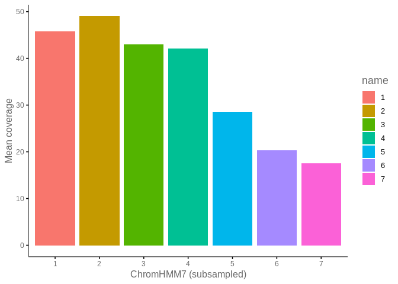

```r
ggplot(summary.score, aes(x=name, y=score, fill=name)) +
  geom_bar(stat='identity') +
  ylab('Mean coverage') +
  xlab('ChromHMM7 (subsampled)') +
  theme_elsasserlab_screen()
```

## Computing binned values on several bigWig files

Many times you will want to look at several `bigWig` files at the same time. For this, you can call `multi_bw_ranges`.

## More documentation

Even though this is a mixed-code package, it is documented as any proper R package is, which means when you’re programming you can access help for functions using `?` operator:

```r
print(?bw_bins)
```